# Adversarial Attacks And Instability: Tricking Resnet

## Chris Tralie

```python
import matplotlib.pyplot as plt
import torch
from torch import nn
from PIL import Image
from torchvision import transforms
import numpy as np
import matplotlib.pyplot as plt
```

First, we'll load in a pretrained version of ResNet from pytorch. [Click here](https://en.wikipedia.org/wiki/Residual_neural_network) to read more about this network. It's able to identify up to 1000 different classes of objects in images

```python
model = torch.hub.load('pytorch/vision:v0.10.0', 'resnet34', pretrained=True)
model.eval()
print(model)
#!wget https://raw.githubusercontent.com/pytorch/hub/master/imagenet_classes.txt
```

```
ResNet(
  (conv1): Conv2d(3, 64, kernel_size=(7, 7), stride=(2, 2), padding=(3, 3), bias=False)
  (bn1): BatchNorm2d(64, eps=1e-05, momentum=0.1, affine=True, track_running_stats=True)
  (relu): ReLU(inplace=True)
  (maxpool): MaxPool2d(kernel_size=3, stride=2, padding=1, dilation=1, ceil_mode=False)
  (layer1): Sequential(
    (0): BasicBlock(
      (conv1): Conv2d(64, 64, kernel_size=(3, 3), stride=(1, 1), padding=(1, 1), bias=False)
      (bn1): BatchNorm2d(64, eps=1e-05, momentum=0.1, affine=True, track_running_stats=True)
      (relu): ReLU(inplace=True)
      (conv2): Conv2d(64, 64, kernel_size=(3, 3), stride=(1, 1), padding=(1, 1), bias=False)
      (bn2): BatchNorm2d(64, eps=1e-05, momentum=0.1, affine=True, track_running_stats=True)
    )
    (1): BasicBlock(
      (conv1): Conv2d(64, 64, kernel_size=(3, 3), stride=(1, 1), padding=(1, 1), bias=False)
      (bn1): BatchNorm2d(64, eps=1e-05, momentum=0.1, affine=True, track_running_stats=True)
      (relu): ReLU(inplace=True)
      (conv2): Conv2d(64, 64, kernel_size=(3, 3), stride=(1, 1), padding=(1, 1), bias=False)
      (bn2): BatchNorm2d(64, eps=1e-05, momentum=0.1, affine=True, track_running_stats=True)
    )
    (2): BasicBlock(
      (conv1): Conv2d(64, 64, kernel_size=(3, 3), stride=(1, 1), padding=(1, 1), bias=False)
      (bn1): BatchNorm2d(64, eps=1e-05, momentum=0.1, affine=True, track_running_stats=True)
      (relu): ReLU(inplace=True)
      (conv2): Conv2d(64, 64, kernel_size=(3, 3), stride=(1, 1), padding=(1, 1), bias=False)
      (bn2): BatchNorm2d(64, eps=1e-05, momentum=0.1, affine=True, track_running_stats=True)
    )
  )
  (layer2): Sequential(
    (0): BasicBlock(
      (conv1): Conv2d(64, 128, kernel_size=(3, 3), stride=(2, 2), padding=(1, 1), bias=False)
      (bn1): BatchNorm2d(128, eps=1e-05, momentum=0.1, affine=True, track_running_stats=True)
      (relu): ReLU(inplace=True)
      (conv2): Conv2d(128, 128, kernel_size=(3, 3), stride=(1, 1), padding=(1, 1), bias=False)
      (bn2): BatchNorm2d(128, eps=1e-05, momentum=0.1, affine=True, track_running_stats=True)
      (downsample): Sequential(
        (0): Conv2d(64, 128, kernel_size=(1, 1), stride=(2, 2), bias=False)
        (1): BatchNorm2d(128, eps=1e-05, momentum=0.1, affine=True, track_running_stats=True)
      )
    )
```

[output cut: 85 more lines]

```
      (relu): ReLU(inplace=True)
      (conv2): Conv2d(512, 512, kernel_size=(3, 3), stride=(1, 1), padding=(1, 1), bias=False)
      (bn2): BatchNorm2d(512, eps=1e-05, momentum=0.1, affine=True, track_running_stats=True)
    )
    (2): BasicBlock(
      (conv1): Conv2d(512, 512, kernel_size=(3, 3), stride=(1, 1), padding=(1, 1), bias=False)
      (bn1): BatchNorm2d(512, eps=1e-05, momentum=0.1, affine=True, track_running_stats=True)
      (relu): ReLU(inplace=True)
      (conv2): Conv2d(512, 512, kernel_size=(3, 3), stride=(1, 1), padding=(1, 1), bias=False)
      (bn2): BatchNorm2d(512, eps=1e-05, momentum=0.1, affine=True, track_running_stats=True)
    )
  )
  (avgpool): AdaptiveAvgPool2d(output_size=(1, 1))
  (fc): Linear(in_features=512, out_features=1000, bias=True)
)
```

```
Using cache found in /home/ctralie/.cache/torch/hub/pytorch_vision_v0.10.0
```

```python
num = 0
for params in model.parameters():
    num += np.prod(params.shape)
print(num/1e6, "million parameters")
```

```
21.797672 million parameters
```

```python
with open("imagenet_classes.txt", "r") as f:
    categories = [s.strip() for s in f.readlines()]
print(categories)
```

```
['tench', 'goldfish', 'great white shark', 'tiger shark', 'hammerhead', 'electric ray', 'stingray', 'cock', 'hen', 'ostrich', 'brambling', 'goldfinch', 'house finch', 'junco', 'indigo bunting', 'robin', 'bulbul', 'jay', 'magpie', 'chickadee', 'water ouzel', 'kite', 'bald eagle', 'vulture', 'great gr…
```

### Image loading/preprocessing

We'll load in a picture of a pizza from the [Collegeville bakery](https://www.collegevilleitalianbakery.com/) and see what resnet says

```
torch.Size([3, 224, 224])
pizza
```

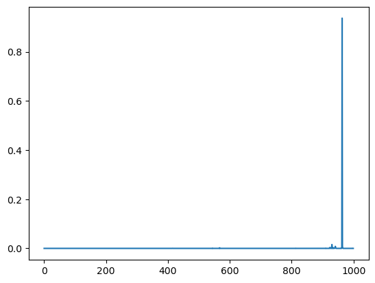

```python
def normalize_img(X):
    """
    Subtract the mean of each channel, and then divide
    by the standard deviation of each channel
    """
    mu = torch.mean(torch.flatten(X, 1, 2), dim=1)
    # Subtract the mean from each pixel
    X = X - mu.view(3, 1, 1)
    # Divide each pixel channel by the standard deviation
    std = torch.std(torch.flatten(X, 1, 2), dim=1)
    X = X/std.view(3, 1, 1)
    return X

input_image = Image.open("collegeville_bakery.jpg")
preprocess = transforms.Compose([
        transforms.Resize(256),
        transforms.CenterCrop(224),
        transforms.ToTensor()
    ]
)
X = preprocess(input_image)
X_Orig = X

XNorm = normalize_img(X)
XNorm = XNorm.unsqueeze(0)
print(X.shape)
probs = model(XNorm)[0, :]
probs = torch.softmax(probs, 0)
idx = torch.argmax(probs)
print(categories[idx])
plt.plot(probs.detach().numpy())
```

## Trick Resnet

We'll now trick resnet into thinking this image is something else by making only very subtle changes to the image

Make the pixels of the image differentiable and tweak them just a little bit until I match a 1 hot vector with something else

During optimization, make sure the pixels stay between 0 and 1

Easiest way to do that is to actually optimize over the inverse of the logistic function on the pixels

## $\sigma(u) = \frac{1}{1+e^{-u}}$

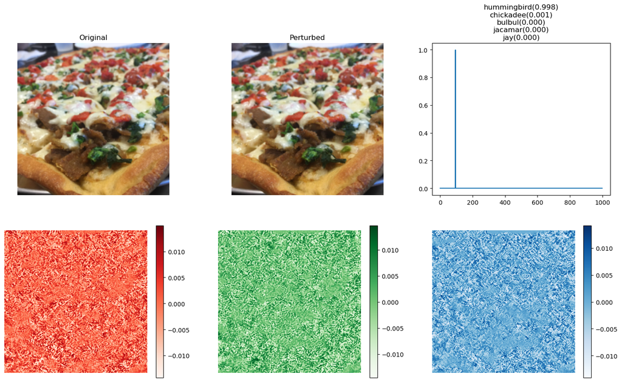

```python
device = 'cuda'
category2idx = {x:i for i, x in enumerate(categories)}

y_target = torch.zeros(1000)
y_target[category2idx["hummingbird"]] = 1

X = torch.logit(X_Orig) # Inverse of logistic function
X = X.to(device)
X = X.requires_grad_() # Makes pixels differentiable

model = model.to(device)
y_target = y_target.to(device)

# Disable gradients on all parameters of resnet to save memory
for p in model.parameters():
    p.requires_grad_(False)

loss_fn = nn.CrossEntropyLoss()
optimizer = torch.optim.Adam([X], lr=1e-3)
n_iters = 100
plot_idx = 0
plt.figure(figsize=(18, 10))
for i in range(n_iters):
    optimizer.zero_grad()
    XNorm = torch.sigmoid(X) # Take back to [0, 1]
    XNorm = normalize_img(XNorm)
    y_est = model(XNorm.unsqueeze(0)).flatten()
    loss = loss_fn(y_est, y_target)
    loss.backward()
    optimizer.step()

    plt.clf()
    plt.subplot(231)
    plt.imshow(np.moveaxis(X_Orig.numpy(), 0, 2))
    plt.axis("off")
    plt.title("Original")
    plt.subplot(232)
    XDisp = torch.sigmoid(X).detach().cpu()
    plt.imshow(np.moveaxis(XDisp.numpy(), 0, 2))
    plt.title("Perturbed")
    plt.axis("off")
    plot_idx += 1
    plt.subplot(233)
    plt.plot(torch.softmax(y_est, 0).detach().cpu())

    top5_prob, top5_id = torch.topk(torch.softmax(y_est, 0), 5)
    s = ["{}({:.3f})".format(categories[i], p) for i, p in zip(top5_id, top5_prob)]
    s = "\n".join(s)
    plt.title(s)

    colors = ["Reds", "Greens", "Blues"]
    for k in range(3):
        plt.subplot(2, 3, 4+k)
        diff = X_Orig[k, :, :] - XDisp[k, :, :]
        plt.imshow(diff, cmap=colors[k])
        plt.axis("off")
        plt.colorbar()
    plt.savefig("Iter{}.png".format(plot_idx))
```

### Training Progress

[figure not shown]

### Zoomed in Result

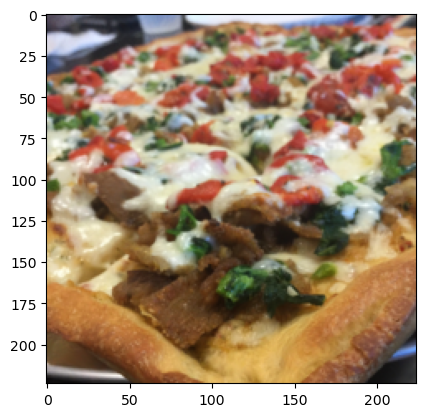

```python
XDisp = torch.sigmoid(X).detach().cpu().numpy()
plt.imshow(np.moveaxis(XDisp, 0, 2))
```

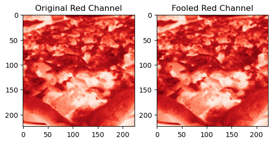

```python
plt.subplot(121)
plt.imshow(X_Orig[0, :, :], cmap="Reds")
plt.title("Original Red Channel")
plt.subplot(122)
plt.imshow(XDisp[0, :, :], cmap="Reds")
plt.title("Fooled Red Channel")
```

### A Mathematical Note on Stability

The upshot is that deep neural networks lack Lipschitz continuity / stability

Def. A function $f$ is k-Lipschitz continuous if

For all $x_1$, $x_2$

### $|f(x_1) - f(x_2)| \leq k|x_1 - x_2|$

Even though deep (convolutional) neural networks lack stability in general, there is a construction called the **Scattering Transform** that fixes the weights as "Morlet wavelets" and fixes the activations as "complex modulus" which turns out to be stable. [Click here](https://www.kymat.io/developerguide.html) to see some code that implements the scattering transform in torch